# Human Activity Recognition ML Project Report

Keith G. Williams

Friday, April 17, 2015

## Executive Summary

A random forest model is used to predict whether a subject is executing a weight lifting exercise correctly. If not, the specific error is predicted. The predicted out of sample accuracy for the best model is 99%.

## Load Data

The data come from  
Velloso, E.; Bulling, A.; Gellersen, H.; Ugulino, W.; Fuks, H. [Qualitative Activity Recognition of Weight Lifting Exercises.](http://groupware.les.inf.puc-rio.br/har) Proceedings of 4th International Conference in Cooperation with SIGCHI (Augmented Human ’13) . Stuttgart, Germany: ACM SIGCHI, 2013.  
These data were collected with body movement sensors while subjects were asked to do weight lifting exercises correctly (Class A) and with 4 common mistakes (Class B, C, D, and E).

```r
library(caret)
library(randomForest)
library(dplyr)

file_train <- "../Data/pml-training.csv"
data_wel <- read.csv(file_train,
                     stringsAsFactors = FALSE,
                     na.strings = c("", "NA", "#DIV/0!"))

# convert classe to factor
data_wel$classe <- factor(data_wel$classe)
```

```r
# remove irrelevant columns
data_wel <- data_wel[-1:-7]
```

## Data Partitioning

```r
set.seed(1201) # set seed for reproducibility
inTrain <- createDataPartition(data_wel$classe, p=0.6, list=FALSE)
training <- data_wel[inTrain,]
testing <- data_wel[-inTrain,]
```

## Exploratory Data Analysis and Preprocessing

It appears that many of the columns have mostly missing data.

```r
proportion_na <- sapply(seq_along(training),
                        function(i) mean(is.na(training[i])))
mean(proportion_na > 0.97)
```

```
## [1] 0.6535948
```

In fact, two-thirds of the variables have more than 97% missing data. These features will likely not be useful for making predictions.

```r
# remove features with > 97% NA
training <- training[proportion_na < 0.97]
testing <- testing[proportion_na < 0.97]
```

Taking a look at one of the remaining features, one can see that there is a difference in variance by classe, so a model is ready to be fitted.

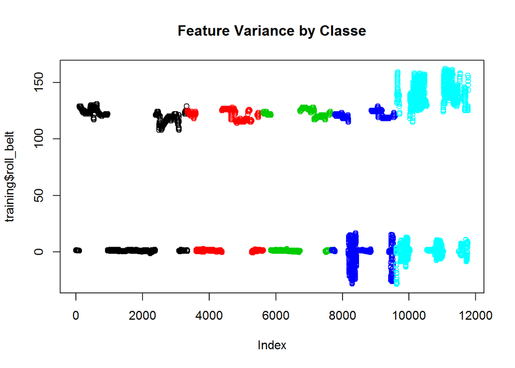

```r
plot(training$roll_belt, col=training$classe, main="Feature Variance by Classe")
```

## Model

The model to be fit is a random forest with bootstrap resampling and 150 trees. Since the features are non-linear, classification trees will provide a better prediction. In addition, the bootstrap aggregation makes a good compromise between bias and reduced variance.

```r
set.seed(6022)
fit <- randomForest(classe ~ ., data = training, ntree = 150)
fit
```

```
##
## Call:
##  randomForest(formula = classe ~ ., data = training, ntree = 150)
##                Type of random forest: classification
##                      Number of trees: 150
## No. of variables tried at each split: 7
##
##         OOB estimate of  error rate: 0.81%
## Confusion matrix:
##      A    B    C    D    E class.error
## A 3343    4    0    0    1 0.001493429
## B   18 2257    4    0    0 0.009653357
## C    0   19 2032    3    0 0.010710808
## D    0    0   31 1895    4 0.018134715
## E    0    0    5    6 2154 0.005080831
```

The predicted out of sample error rate is > 0.81%.

The random forest error doesn’t get any better after around 100 trees, so even 150 trees is more than enough to get the best prediction from the given features.

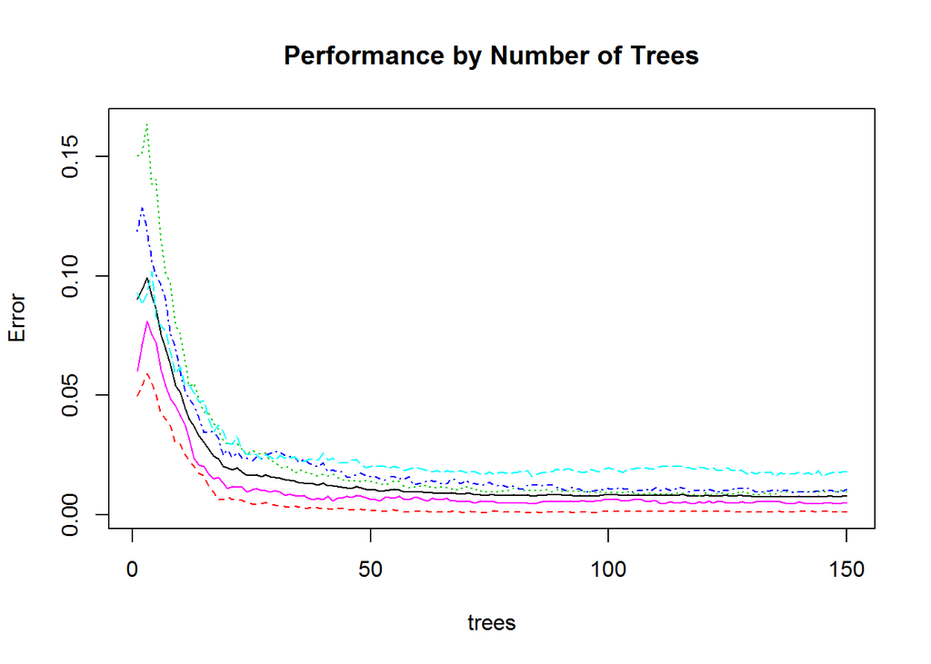

```r
plot(fit, main="Performance by Number of Trees")
```

## Cross Validation

With a predicted out of sample accuracy greater than 99%, overfitting is a concern. The remaining 40% of the training data will be used to cross validate the model.

```r
cv <- predict(fit, select(testing, -classe))
confusionMatrix(testing$classe, cv)
```

```
## Confusion Matrix and Statistics
##
##           Reference
## Prediction    A    B    C    D    E
##          A 2231    0    0    0    1
##          B   14 1504    0    0    0
##          C    0   11 1356    1    0
##          D    0    0   17 1269    0
##          E    0    0    1    2 1439
##
## Overall Statistics
##
##                Accuracy : 0.994
##                  95% CI : (0.992, 0.9956)
##     No Information Rate : 0.2861
##     P-Value [Acc > NIR] : < 2.2e-16
##
##                   Kappa : 0.9924
##  Mcnemar's Test P-Value : NA
##
## Statistics by Class:
##
##                      Class: A Class: B Class: C Class: D Class: E
## Sensitivity            0.9938   0.9927   0.9869   0.9976   0.9993
## Specificity            0.9998   0.9978   0.9981   0.9974   0.9995
## Pos Pred Value         0.9996   0.9908   0.9912   0.9868   0.9979
## Neg Pred Value         0.9975   0.9983   0.9972   0.9995   0.9998
## Prevalence             0.2861   0.1931   0.1751   0.1621   0.1835
## Detection Rate         0.2843   0.1917   0.1728   0.1617   0.1834
## Detection Prevalence   0.2845   0.1935   0.1744   0.1639   0.1838
## Balanced Accuracy      0.9968   0.9953   0.9925   0.9975   0.9994
```

The cross-validated model has an accuracy of $99.4\% \pm 0.2\%$